# Using Models 1

Sonja

3/11/2021

## Learning Objectives

Conduct commonly used tests on categorical data

### Key Concepts

- Analysis of categorical data: 1- and 2-sample tests
- Testing assumptions: normality
- Interpreting test output

```
## here() starts at C:/Users/Zonj/Documents/Universites_Research/UMass/courses/ECO 602_634 environ stats/environmental_data
```

### Numerical and Graphical exploration

##### Q1

The values of the cat.rate collumn does not appear to be normally distributed.

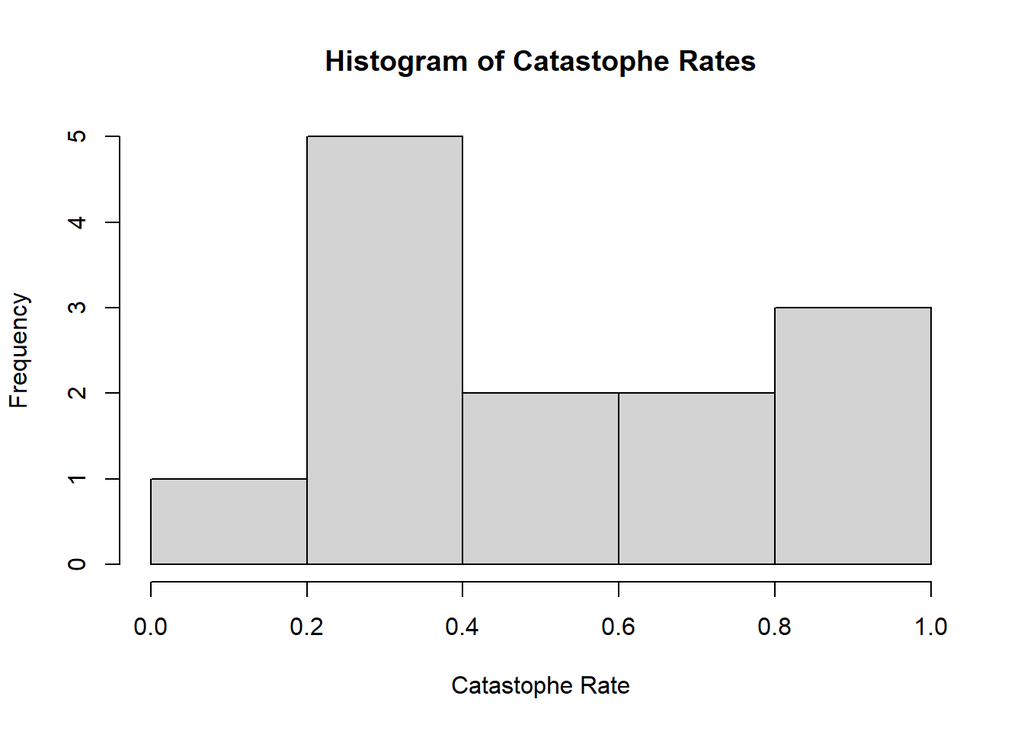

```r
hist(catrate$cat.rate, main = "Histogram of Catastophe Rates", xlab="Catastophe Rate")
```

### Check for Normality

##### Q2

p-value = 0.04097

```r
shapiro.test(catrate$cat.rate)
```

```
##
##  Shapiro-Wilk normality test
##
## data:  catrate$cat.rate
## W = 0.86202, p-value = 0.04097
```

##### Q3

The null hypothesis for the shapiro test is that the data were sampled from a normally-distributed population.

### One-Sample Tests: Tests for Difference From Expectation

#### Parametric One-Sample Test: The t-test

##### Q5

```r
t.test(catrate$cat.rate,
       alternative = c("two.sided"),
       mu = 0.2857143,
       conf.level = 0.95)
```

```
##
##  One Sample t-test
##
## data:  catrate$cat.rate
## t = 2.9595, df = 12, p-value = 0.01193
## alternative hypothesis: true mean is not equal to 0.2857143
## 95 percent confidence interval:
##  0.3526250 0.7261295
## sample estimates:
## mean of x
## 0.5393773
```

##### Q6

The null hypothesis is that the true mean is equal to 0.2857143.

##### Q7

This is a two-tailed test.

##### Q8

If we were to go out and sample for the catastrophic rate of salamander eggs and we happened to observed many dry ponds and therefore a recorded a high catastrophic rate, it is possible that we what we observed is not true for the entire system and that in actuality the catastrophic rate is smaller.

##### Q10

Based on the results from the t-test there is strong evidence to reject the null hypothesis. The p-value is 0.0119 meaning that it is very unlikely to observe the catastrophic rate we observed if the mean of the catastrophic rate was actually 0.28

#### One-sided Alternative Hypothesis

##### “greater”

```r
t.test(catrate$cat.rate, y = NULL,
       alternative = "greater",
       mu = 0.2857143,
       conf.level = 0.95)
```

```
##
##  One Sample t-test
##
## data:  catrate$cat.rate
## t = 2.9595, df = 12, p-value = 0.005966
## alternative hypothesis: true mean is greater than 0.2857143
## 95 percent confidence interval:
##  0.3866123       Inf
## sample estimates:
## mean of x
## 0.5393773
```

##### “less”

```r
t.test(catrate$cat.rate, y = NULL,
       alternative = "less",
       mu = 0.2857143,
       conf.level = 0.95)
```

```
##
##  One Sample t-test
##
## data:  catrate$cat.rate
## t = 2.9595, df = 12, p-value = 0.994
## alternative hypothesis: true mean is less than 0.2857143
## 95 percent confidence interval:
##       -Inf 0.6921422
## sample estimates:
## mean of x
## 0.5393773
```

It shows that it is very unlikely that the carastrophic rate would be less than .28.

##### Q11

```r
wilcox.test(catrate$cat.rate,
            mu = 2 / 7)
```

```
##
##  Wilcoxon signed rank test with continuity correction
##
## data:  catrate$cat.rate
## V = 85, p-value = 0.006275
## alternative hypothesis: true location is not equal to 0.2857143
```

##### Q12

The p value from the Wilcox test is 0.0063, which is lower that the t-test’s p value

##### Q13

Yes there is strong evidence to reject the null hypothesis because the low p-value of 0.0063 from the Wilcox test means that the true mean is not equal to 2/7.

##### Q14

The Wilcox test and the one-sample t tests show that it is very unlikely that the mean of the catastrophic reproduction rate is 2/7. The sample mean is actually 0.5393 which suggests the the catastrophic rate is not closely related to the rate of lake filling.

##### Q15

The Wilcox test is definitely better for this data set because of the clear violations of the normality assumption that is required for a t-test.

##### Q16

### Comparing two sample means

##### Q16

```r
# Extract the Adelie penguin data
dat_adelie = subset(penguin_dat, species == "Adelie")
# Extract the Chinstrap penguin data
dat_chin = subset(penguin_dat, species == "Chinstrap")
```

```r
sh<-aggregate(flipper_length_mm ~ species,
          data=penguin_dat,
          FUN=function(x) shapiro.test(x)$p.value)

sh
```

```
##     species flipper_length_mm
## 1    Adelie         0.7200466
## 2 Chinstrap         0.8106447
```

##### Q17

For Adelie penguins the Shapiro test p value was 0.72 and for the Chinstrap was p value 0.81 meaning that the null hypothesis cannot be rejected and that the data for both groups is normally distributed.

##### Q18

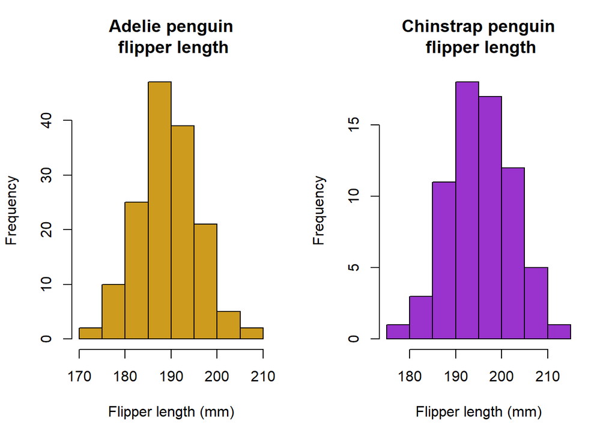

##### Q19

The alternative hypothesis is that the mean flipper length of Adelie penguins and Chinstrap penguins is different.

##### Q20

```r
t.test(flipper_length_mm~species, data=penguin_dat,
       alternative = "two.sided")
```

```
##
##  Welch Two Sample t-test
##
## data:  flipper_length_mm by species
## t = -5.7804, df = 119.68, p-value = 6.049e-08
## alternative hypothesis: true difference in means is not equal to 0
## 95 percent confidence interval:
##  -7.880530 -3.859244
## sample estimates:
##    mean in group Adelie mean in group Chinstrap
##                189.9536                195.8235
```